# Introdução ao R Commander

O objetivo deste tutorial é familiarizar o estudante com o software estatístico R Commander, uma interface gráfica para o R, desenvolvida para permitir ao usuário maior facilidade no uso da linguagem. O principal objetivo de se introduzir R Commander nesta disciplina é facilitar o acesso aos métodos estatísticos disponíveis na linguagem R. Assim o pesquisador deve aprender a usar os principais comandos, menus de organização e recuperação de dados em planilhas a partir do uso deste software.

# Table of Contents

## O que você deve saber antes de usar o R Commander

Para se instalar o **R Commander**, seu computador também precisa do R instalado.

Como o R Commander é disponível para diversas plataformas, presume-se que o estudante saiba utilizar seu computador. É necessário saber como baixar um arquivo da Internet (download), criar uma pasta (diretório) em seu computador, e encontrá-lo posteriormente. No tutorial de Minitab existe uma descrição das tarefas básicas que talvez lhe interesse observar.

Esta série de tutoriais foi inicialmente ilustrada com o R Commander versão 1.8-1, R na versão 2.14.1, rodando sob Linux (especificamente, Ubuntu, versão 12.04 LTS, em inglês). No entanto, espera-se que os usuários também explorem outras plataformas e versões de programas. Deveão ser capazes de utilizar outros sistemas operacionais, com outras configurações de tela e/ou versões diferentes do R Commander e do R, e portanto haverá telas com aspectos ligeiramente diferentes, mas sem perturbar o entendimento do tutorial.

Caso encontre alguma discrepância maior, não hesite em nos alertar sobre as eventuais diferenças dos sistemas ou versões.

Para que todos usem o R Commander em **português** ou **inglês**, ao seu gosto, padronizamos usar os comandos nas duas versões na medida do possível. Por exemplo:

$\ $Estatísticas -> Médias -> Teste t para amostras independentes

$\ $Statistics -> Means -> Independent samples t-test

e, dentro do texto, colocaremos em **português** (e **inglês entre parênteses**).

## Por que R Commander?

Recomendamos fortemente o aprendizado adicional do R Commander porque lhes permitirá aprofundar nos recursos de análises estatísticas complexas em R, pois pela escolha por meio de interface gráfica o R Commander mostrará os comandos em R no console, sem a necessidade de se consultar manuais ou outras fontes. R Commander (Rcmdr) e seus plugins são um programa ou pacotes R de código aberto e de uso livre. Pesquisadores ou alunos familiarizados com o R Commander poderão utilizá-los em suas tarefas, não dependendo de licenças institucionais ou da compra para uso pessoal. O R Commander também mostra, enquanto opera, como são os comandos R que constrói para você. No futuro, ou precisando de usos mais avançados, você poderá aprender R, que é uma linguagem de programação forte em estatística, mas com vários outros recursos. Programar em R é outro nível, mas as possibilidades são muito mais amplas.

### O R Commander:

- Apresenta organização de menus semelhantes aos de aplicativos comumente utilizados, como processadores de texto (e.g. Word, LibreOffice Writer) e planilhas eletrônicas (e.g., Excel, Gnumeric, LibreOffice Calc), facilitando seu aprendizado; e
- Incorpora uma série de recursos de manipulação de dados, de confecção de gráﬁco e de rotinas de análise estatística mais importantes que irão satisfazer a maioria das necessidades de estudantes e pesquisadores na área biomédica.

Pretende-se introduzir o [R Commander](http://www.rcommander.com/), comumente abreviado para *Rcmdr*, mostrando algumas rotinas de manipulação de arquivos que serão úteis para resolução de problemas práticos de análise de dados em medicina.

Não é possível esgotar todas as possibilidades e recursos oferecidos pelo R em poucas aulas, mas esperamos poder mostrar algumas novas perspectivas de uso prático de um pacote estatístico que também tem os principais recursos de um programa de planilha eletrônica, semelhante ao **Excel** (Microsoft), ou **OpenOﬃce/LibreOffice** (este um programa livre).

Para aqueles mais curiosos, sugere-se a leitura do [manual disponível na página dos autores](http://socserv.mcmaster.ca/jfox/Misc/Rcmdr). Os testes estatísticos propriamente ditos serão introduzidos ao longo das aulas práticas subsequentes.

## Abrindo o programa

### No Linux

Inicie o R Commander. No Ubuntu, versão 12.04 LTS está em

Applications -> Science -> R Commander

Um terminal abre-se primeiro e o R é ativado:

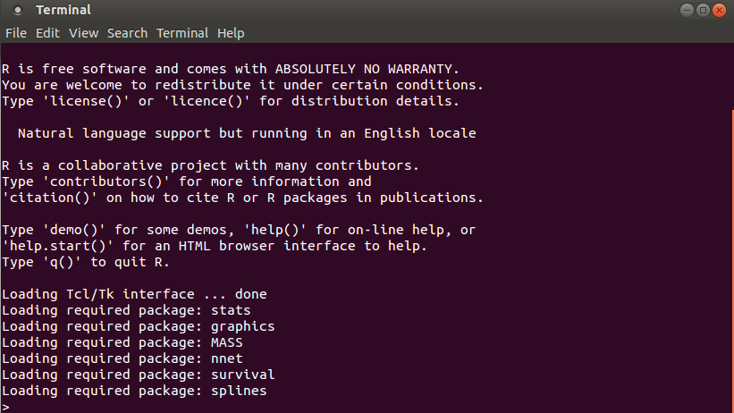

em seguida aparece a interface gráfica do R Commander:

[figure not shown]

O terminal pode ser minimizado, mas não deve ser fechado. Este terminal é totalmente funcional e pode ser utilizado simultaneamente ao Rcmdr. Experimente escrever no terminal o comando R version após o sinal de ">" (este é o prompt do R). Deve obter algo como:

```
> version
               _
platform       i686-pc-linux-gnu
arch           i686
os             linux-gnu
system         i686, linux-gnu
status
major          2
minor          14.1
year           2011
month          12
day            22
svn rev        57956
language       R
version.string R version 2.14.1 (2011-12-22)
>
```

### No Macintosh

A ser descrito por um usuário deste sistema operacional.

### No Windows

Na área de trabalho do Windows encontre e utilize o acesso ao R, que abre a RGui, uma interface gráfica que facilita o uso do R e contém um terminal.

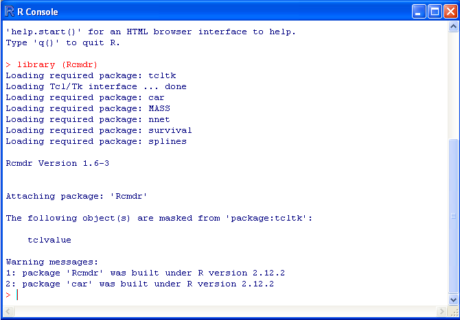

Neste terminal (como mostrado acima) digite o comando:

```
> library(Rcmdr)
```

A janela do R Commander deve abrir:

[figure not shown]

Da mesma forma que acontece em outras plataformas, o terminal é funcional (pode testar com o comando version, como descrito para a implementação em Linux). O terminal pode ser minimizado, mas não deve ser fechado.

## Manipulação dos dados

### Abrindo uma planilha de dados existente

Os dados que utilizaremos aqui estão no arquivo [exames1.txt](https://github.com/mdr5728r/2020/blob/master/Rcmdr_tutorial/Rcmdr_Intro/exames1.txt?raw=true), que você deve baixar para seu computador (dependendo da configuração de seu computador e navegador, experimente usar o botão da direita do mouse para fazer este download). Este arquivo de dados é apresentado em texto puro, delimitado por "tabs", e precisa ser importado pelo Rcmdr, como descrito abaixo.

Este arquivo de dados tem o mesmo conteúdo da planilha Excel [exames1.xls](https://github.com/mdr5728r/2020/blob/master/Rcmdr_tutorial/Rcmdr_Intro/exames1.xls?raw=true). O R Commander nas versões atualmente (2014) disponíveis para Linux e Macintosh não abrem planilhas Excel diretamente, mas (curiosamente) abrem arquivos do Minitab. Caso você tenha dados em Excel, pode gerar um arquivo texto, como fizemos.

Arquivos textos com delimitadores são a forma mais universal de transpor dados entre programas diferentes e, portanto, vale a pena saber lidar com eles. Ouvi dizer que na versão mais nova em Windows o Rcmdr importa planilhas Excel. Com a versão 2016 no Windows 10 foi possível importar planilha Excel. O procedimento é o mesmo: Dados -> Importar arquivo de dados... a última opção é arquivo do Excel.

Acesse, no Rcmdr:

$\ $Dados -> Importar conjunto de dados -> de arquivo de texto ...  
$\ $Data -> Import data -> from text file ...

[figure not shown]

A caixa de diálogo que aparece:

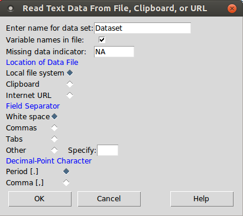

precisa ser configurada de acordo com o formato do arquivo texto:

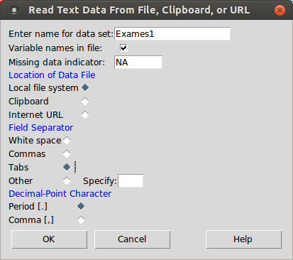

Note as seguintes opções que fizemos:

- **Defina o nome do conjunto de dados (Enter name for data set)**: Exames1 (apenas para que lembremos de qual arquivo os dados vieram);
- **Nome das varíaveis no arquivo (Variable names in file)**: selecionado (porque, neste arquivo, a primeira linha contém os nomes das variáveis, o que é sempre recomendado);
- **Separador de campos (Field separator)**: Tabs (porque foi o delimitador que utilizamos ao gerar exames1.txt);
- **Separador de decimais (Decimal-point character)**: Period (no caso, foi como exportamos os dados numéricos).

Para importar os dados: clique **[Ok]** e aponte o arquivo de dados que você baixou. Repare o comando R ecoado na **Output (Output Windows)**: este é o comando que você precisaria escrever em R, caso usasse a linha de comando, para importar este arquivo. É deste trabalho que o Rcmdr o poupa:

```
Exames1 <- read.table("/home/usuario/Aulas/MDR5728/Rcmdr_tutorial/Rcmdr_Intro/MPT0164_exames1.txt", header=TRUE, sep="\t", na.strings="NA", dec=".", strip.white=TRUE)
```

Se tudo estiver correto, na tela de mensagens deve aparecer:

NOTA: Os dados Exames1 tem 705 linhas e 15 colunas.  
NOTE: The dataset Exames1 has 705 rows and 15 columns.

### Números: vírgulas ou pontos

O uso de vírgula ou de ponto como separador decimal dá problema entre computadores utilizando português ou inglês. Particularmente (opinião de Paulo Silveira), prefiro desrespeitar a gramática para trabalhar e **sempre** utilizar o ponto (trocando para vírgulas somente no que preciso publicar em português). Caso sua opção seja outra, saiba que isto depende da configuração do computador utilizado no momento da exportação dos dados para o arquivo **txt** e do que você selecionar no R Commander no momento de importar os dados para o data set. Verifique como está o seu computador. Veja opinião do Prof. Koichi Sameshima, algo divergente em Uma Pausa: cuidado no uso da vírgula decimal.

## Visualizando os dados

Após importar os dados, um conjunto de dados (data set) com o nome que você escolheu está ativo. Você pode conferir se a importação dos dados deu certo clicando em **Ver conjunto de dados ([View data set])** para abrir esta janela:

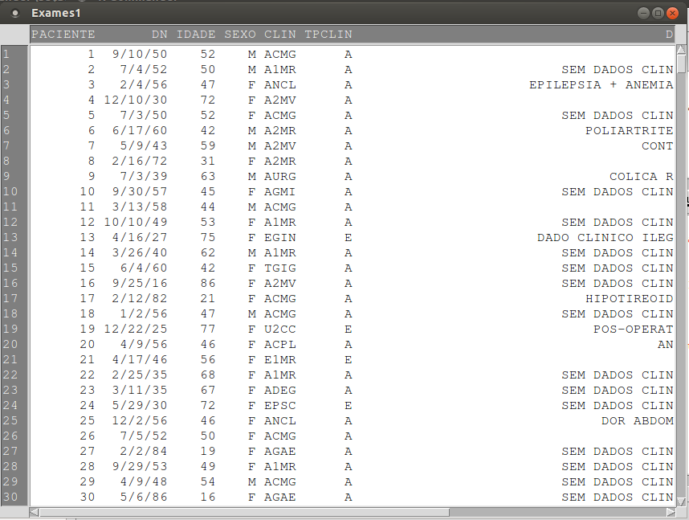

Nesta tela aparecem os dados importados. Há também barras de rolagens horizontal e vertical, para que você possa percorrê-los. Antes de prosseguir, identiﬁque os elementos que compõem a janela em questão, pois é fundamental entender como os dados ficam organizados:

- note que os dados de cada paciente estão organizados em linhas, identiﬁcadas na coluna à esquerda enumeradas a partir de 1 (o número de cada linha coincide com o número de identificação do paciente, mas isto é somente coincidência);
- observe que cada coluna, denominada variável, é encimada por sua identiﬁcação, o nome da variável. É através deste identiﬁcador, importado da primeira linha do arquivo texto, que você referenciará as variáveis que desejar para executar os procedimentos adiante.  
  **Dica**: não utilize espaços ou símbolos especiais (o Rcmdr aceita "." se precisar de nomes compostos) para compor nome de identiﬁcadores; também recomenda-se iniciar os nomes das variáveis com uma letra.

Depois que verificar o sucesso da importação, sugere-se que esta janela seja fechada.

O Rcmdr trabalha com conjuntos de dados (data sets). Você pode ter mais que um conjunto de dados simultaneamente aberto em uma mesma seção do Rcmdr, mas os comandos são executados apenas com o conjunto ativo. A qualquer momento você pode alterar o conjunto ativo através de Dados -> conjunto de dados ativos (Data->Active data set) ou clicando sobre o botão que aparece contendo o nome do data set ativo.

Ao lado do botão **[Ver conjunto de dados]** (**[View data set]**) aparece **[Editar conjunto de dados]** (**[Edit data set]**), o qual obviamente permite modificar os dados. A interface de edição não é muito boa. Caso precise de alterações mais extensas, é melhor arrumar os dados em uma planilha e importar novamente. Há mais detalhes sobre este editor abaixo.

## Salvando e recuperando dados

Este conjunto de dados pode ser salvo no formato do R Commander para usar mais tarde (assim não é necessário repetir a importação). Esta operação, bem como várias outras, encontra-se em:

$\ $Dados -> conjuntos de dados ativos -> salvar conjunto de dados ativos...

$\ $Data->Active data set->Save active data set...

Escolha a pasta e grave o arquivo que recebe o nome do data set e a extensão Rdata: no exemplo o arquivo gerado é Exames1.RData. Por esta razão, procure escolher nomes com significado para seus conjuntos de dados; não os chame de dados, planilha, pacientes, ou coisas similares. Quando quiser voltar a trabalhar com o mesmo conjunto de dados, busque-o com:

$\ $Dados -> Carregar conjunto de dados

$\ $Data->Load data set...